# Heart_Failure_Prediction_Final

```
[18:42:46] WARNING: C:/Users/Administrator/workspace/xgboost-win64_release_1.4.0/src/learner.cc:1095: Starting in XGBoost 1.3.0, the default evaluation metric used with the objective 'binary:logistic' was changed from 'error' to 'logloss'. Explicitly set eval_metric if you'd like to restore the old …
{'colsample_bylevel': 1.0, 'colsample_bytree': 1.0, 'gamma': 1.5, 'learning_rate': 0.5, 'max_depth': 6, 'min_child_weight': 3, 'n_estimators': 500, 'nthread': 2, 'subsample': 0.8}
Report Para Dados de Teste
```

```
AUC: 0.702940
```

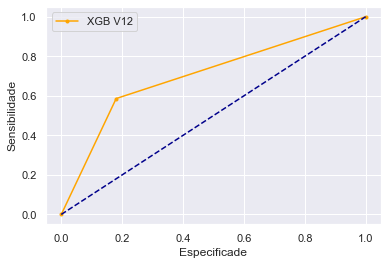

```
Acurácia: 0.744444
              precision    recall  f1-score   support

       VIVER       0.81      0.82      0.81        61
      MORRER       0.61      0.59      0.60        29

    accuracy                           0.74        90
   macro avg       0.71      0.70      0.70        90
weighted avg       0.74      0.74      0.74        90

Report Para Dados de Treino
Acurácia: 0.901408
              precision    recall  f1-score   support

       VIVER       0.88      0.93      0.90       142
      MORRER       0.93      0.87      0.90       142

    accuracy                           0.90       284
   macro avg       0.90      0.90      0.90       284
weighted avg       0.90      0.90      0.90       284

Wall time: 5min 54s
```

```python
%%time

params = {
        'min_child_weight': [1, 2, 3, 4],
        'gamma': [0.7, 1.3, 1.4, 1.5],
        'subsample': [0.6, 0.8, 0.9, 1.0],
        'colsample_bytree': [0.8, 0.9, 1.0],
        'colsample_bylevel': [0.8, 0.9, 1.0],
        'max_depth': [5, 6, 7],
        'learning_rate': [0.5, 0.1, 0.01],
        'nthread': [2],
        'n_estimators' : [500]
        }

# Criação do modelo v12
# Criando com padronização, balanceamento e feature selecting
modelo_grid = xgb.XGBClassifier(use_label_encoder = False)

resultados = treina_GridSearchCV(modelo_grid, params, x_train_resample, y_train_resample,\
                                 x_test, y_test, title = 'XGB V12', report_treino = True,\
                                 salvar_resultados = True)
```

```
[18:48:39] WARNING: C:/Users/Administrator/workspace/xgboost-win64_release_1.4.0/src/learner.cc:1095: Starting in XGBoost 1.3.0, the default evaluation metric used with the objective 'binary:logistic' was changed from 'error' to 'logloss'. Explicitly set eval_metric if you'd like to restore the old …
{'colsample_bynode': 1.0, 'colsample_bytree': 1.0, 'gamma': 1.5, 'learning_rate': 0.5, 'max_depth': 6, 'min_child_weight': 3, 'n_estimators': 500, 'nthread': 2, 'subsample': 0.8}
Report Para Dados de Teste
```

```
AUC: 0.702940
```

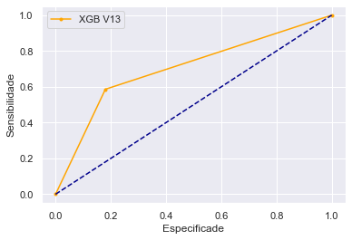

```
Acurácia: 0.744444
              precision    recall  f1-score   support

       VIVER       0.81      0.82      0.81        61
      MORRER       0.61      0.59      0.60        29

    accuracy                           0.74        90
   macro avg       0.71      0.70      0.70        90
weighted avg       0.74      0.74      0.74        90

Report Para Dados de Treino
Acurácia: 0.901408
              precision    recall  f1-score   support

       VIVER       0.88      0.93      0.90       142
      MORRER       0.93      0.87      0.90       142

    accuracy                           0.90       284
   macro avg       0.90      0.90      0.90       284
weighted avg       0.90      0.90      0.90       284

Wall time: 5min 53s
```

```python
%%time

params = {
        'min_child_weight': [1, 2, 3, 4],
        'gamma': [0.7, 1.3, 1.4, 1.5],
        'subsample': [0.6, 0.8, 0.9, 1.0],
        'colsample_bytree': [0.8, 0.9, 1.0],
        'colsample_bynode': [0.8, 0.9, 1.0],
        'max_depth': [5, 6, 7],
        'learning_rate': [0.5, 0.1, 0.01],
        'nthread': [2],
        'n_estimators' : [500]
        }

# Criação do modelo v13
# Criando com padronização, balanceamento e feature selecting
modelo_grid = xgb.XGBClassifier(use_label_encoder = False)

resultados = treina_GridSearchCV(modelo_grid, params, x_train_resample, y_train_resample,\
                                 x_test, y_test, title = 'XGB V13', report_treino = True,\
                                 salvar_resultados = True)
```

[output not shown]

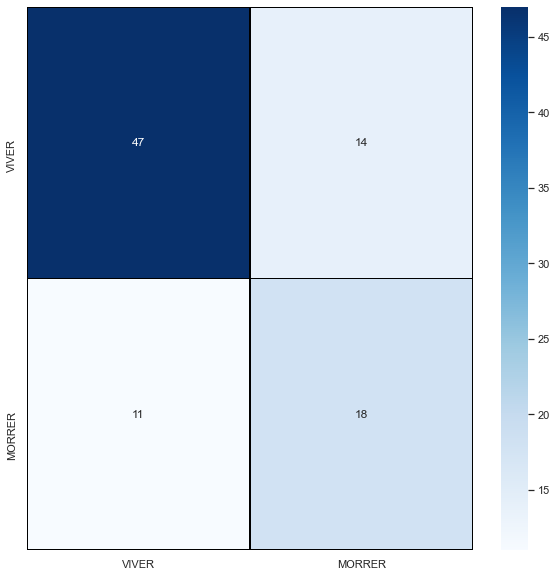

```
AUC: 0.695591
```

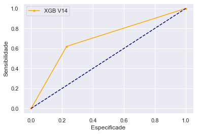

```
Acurácia: 0.722222
              precision    recall  f1-score   support

       VIVER       0.81      0.77      0.79        61
      MORRER       0.56      0.62      0.59        29

    accuracy                           0.72        90
   macro avg       0.69      0.70      0.69        90
weighted avg       0.73      0.72      0.73        90
```

```python
#Transformando os dados em DMatrix pois o XGBoost exige
dtrain = xgb.DMatrix(x_train_resample, label = y_train_resample)
dtest = xgb.DMatrix(x_test, label = y_test)

params = {'colsample_bynode': 0.3, 'colsample_bytree': 1.0, 'gamma': 1.5, 'learning_rate': 0.5, 'max_depth': 10,\
          'min_child_weight': 1, 'n_estimators': 1000, 'nthread': 2, 'subsample': 0.8}

# Criação do modelo base v14
# Criando com padronização, balanceamento e feature selecting
modelo_xgb_v14 = xgb.train(params = params, dtrain = dtrain)

pred_v14 = modelo_xgb_v14.predict(dtest)

report_modelo(modelo_xgb_v14, y_test_nothing, pred_v14, label = 'XGB V14', target_names = ['VIVER', 'MORRER'])
```

[output not shown]

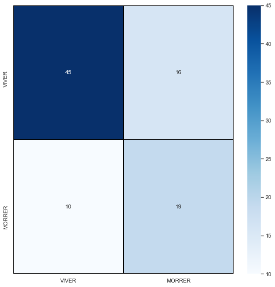

```
AUC: 0.696439
```

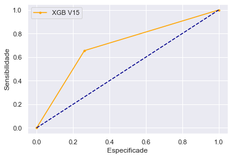

```
Acurácia: 0.711111
              precision    recall  f1-score   support

       VIVER       0.82      0.74      0.78        61
      MORRER       0.54      0.66      0.59        29

    accuracy                           0.71        90
   macro avg       0.68      0.70      0.68        90
weighted avg       0.73      0.71      0.72        90
```

```python
#Transformando os dados em DMatrix pois o XGBoost exige
dtrain = xgb.DMatrix(x_train_resample, label = y_train_resample)
dtest = xgb.DMatrix(x_test, label = y_test)

params = {'colsample_bynode': 0.3, 'colsample_bytree': 1.0, 'gamma': 2.3, 'learning_rate': 0.5, 'max_depth': 12,\
          'min_child_weight': 1, 'n_estimators': 500, 'nthread': 2, 'subsample': 0.8}

# Criação do modelo base v15
# Criando com padronização, balanceamento e feature selecting
modelo_xgb_v15 = xgb.train(params = params, dtrain = dtrain)

pred_v15 = modelo_xgb_v15.predict(dtest)

report_modelo(modelo_xgb_v15, y_test_nothing, pred_v15, label = 'XGB V15', target_names = ['VIVER', 'MORRER'])
```

[output not shown]

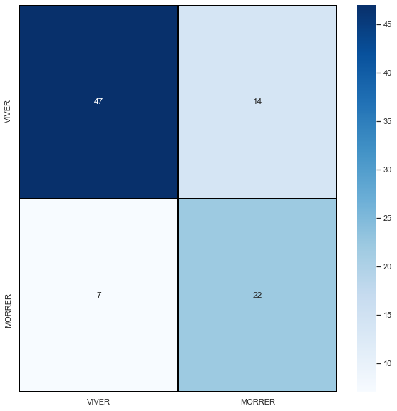

```
AUC: 0.764556
```

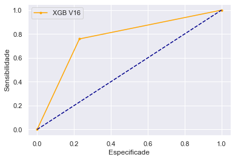

```
Acurácia: 0.766667
              precision    recall  f1-score   support

       VIVER       0.87      0.77      0.82        61
      MORRER       0.61      0.76      0.68        29

    accuracy                           0.77        90
   macro avg       0.74      0.76      0.75        90
weighted avg       0.79      0.77      0.77        90

Report Para Dados de Treino
Acurácia: 0.728873
              precision    recall  f1-score   support

       VIVER       0.70      0.80      0.75       142
      MORRER       0.76      0.66      0.71       142

    accuracy                           0.73       284
   macro avg       0.73      0.73      0.73       284
weighted avg       0.73      0.73      0.73       284

Wall time: 264 ms
```

```python
%%time

#Transformando os dados em DMatrix pois o XGBoost exige
dtrain_sc_resample = xgb.DMatrix(x_train_sc_resample, label = y_train_resample_2)
dtest_sc = xgb.DMatrix(x_test_sc, label = y_test_nothing)

params = {'colsample_bynode': 0.6, 'colsample_bytree': 0.3, 'gamma': 2.3, 'learning_rate': 0.5, 'max_depth': 12,\
          'min_child_weight': 1, 'n_estimators': 500, 'nthread': 2, 'subsample': 0.8}

# Criação do modelo base v16
# Criando sem feature selecting. Com padronização e balanceamento
modelo_xgb_v16 = xgb.train(params = params, dtrain = dtrain_sc_resample)

pred_v16 = modelo_xgb_v16.predict(dtest_sc)

report_modelo(modelo_xgb_v16, y_test_nothing, pred_v16, label = 'XGB V16', target_names = ['VIVER', 'MORRER'])

print('Report Para Dados de Treino')
pred_treino = modelo_xgb_v16.predict(dtrain_sc_resample)
pred_treino = pred_treino > 0.5

# Acurácia
print("Acurácia: %f" % accuracy_score(y_train_resample_2, pred_treino))

# Classification Report
print(classification_report(y_train_resample_2, pred_treino, target_names= ['VIVER', 'MORRER']))
```

[output not shown]

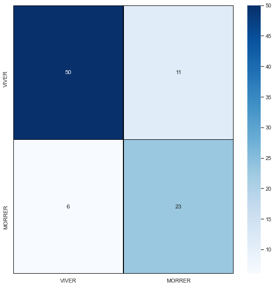

```
AUC: 0.806388
```

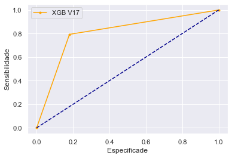

```
Acurácia: 0.811111
              precision    recall  f1-score   support

       VIVER       0.89      0.82      0.85        61
      MORRER       0.68      0.79      0.73        29

    accuracy                           0.81        90
   macro avg       0.78      0.81      0.79        90
weighted avg       0.82      0.81      0.81        90

Report Para Dados de Treino
Acurácia: 0.781690
              precision    recall  f1-score   support

       VIVER       0.77      0.81      0.79       142
      MORRER       0.80      0.75      0.78       142

    accuracy                           0.78       284
   macro avg       0.78      0.78      0.78       284
weighted avg       0.78      0.78      0.78       284

Wall time: 268 ms
```

```python
%%time

#Transformando os dados em DMatrix pois o XGBoost exige
dtrain_sc_resample = xgb.DMatrix(x_train_sc_resample, label = y_train_resample_2)
dtest_sc = xgb.DMatrix(x_test_sc, label = y_test_nothing)

params = {'colsample_bynode': 0.6, 'colsample_bytree': 0.5, 'gamma': 2.3, 'learning_rate': 0.5, 'max_depth': 12,\
          'min_child_weight': 1, 'n_estimators': 500, 'nthread': 2, 'subsample': 0.8}

# Criação do modelo base v17
# Criando sem feature selecting. Com padronização e balanceamento
modelo_xgb_v17 = xgb.train(params = params, dtrain = dtrain_sc_resample)

pred_v17 = modelo_xgb_v17.predict(dtest_sc)

report_modelo(modelo_xgb_v17, y_test_nothing, pred_v17, label = 'XGB V17', target_names = ['VIVER', 'MORRER'])

print('Report Para Dados de Treino')
pred_treino = modelo_xgb_v17.predict(dtrain_sc_resample)
pred_treino = pred_treino > 0.5

# Acurácia
print("Acurácia: %f" % accuracy_score(y_train_resample_2, pred_treino))

# Classification Report
print(classification_report(y_train_resample_2, pred_treino, target_names= ['VIVER', 'MORRER']))
```

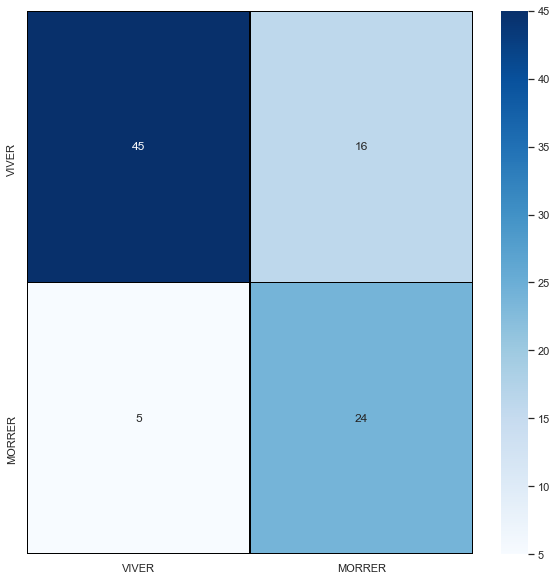

```
AUC: 0.782646
```

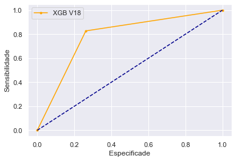

```
Acurácia: 0.766667
              precision    recall  f1-score   support

       VIVER       0.90      0.74      0.81        61
      MORRER       0.60      0.83      0.70        29

    accuracy                           0.77        90
   macro avg       0.75      0.78      0.75        90
weighted avg       0.80      0.77      0.77        90

Report Para Dados de Treino
Acurácia: 0.750000
              precision    recall  f1-score   support

       VIVER       0.77      0.71      0.74       142
      MORRER       0.73      0.79      0.76       142

    accuracy                           0.75       284
   macro avg       0.75      0.75      0.75       284
weighted avg       0.75      0.75      0.75       284

Wall time: 420 ms
```

```python
%%time

#Transformando os dados em DMatrix pois o XGBoost exige
dtrain_sc_resample = xgb.DMatrix(x_train_sc_resample, label = y_train_resample_2)
dtest_sc = xgb.DMatrix(x_test_sc, label = y_test_nothing)

params = {'colsample_bynode': 0.6, 'colsample_bytree': 0.5, 'gamma': 2.3, 'learning_rate': 0.5, 'max_depth': 12,\
          'min_child_weight': 1, 'nthread': 2, 'subsample': 0.789}

# Criação do modelo base v18
# Criando sem feature selecting. Com padronização e balanceamento
modelo_xgb_v18 = xgb.train(params = params, dtrain = dtrain_sc_resample)

pred_v18 = modelo_xgb_v18.predict(dtest_sc)

report_modelo(modelo_xgb_v18, y_test_nothing, pred_v18, label = 'XGB V18', target_names = ['VIVER', 'MORRER'])

print('Report Para Dados de Treino')
pred_treino = modelo_xgb_v18.predict(dtrain_sc_resample)
pred_treino = pred_treino > 0.5

# Acurácia
print("Acurácia: %f" % accuracy_score(y_train_resample_2, pred_treino))

# Classification Report
print(classification_report(y_train_resample_2, pred_treino, target_names= ['VIVER', 'MORRER']))
```

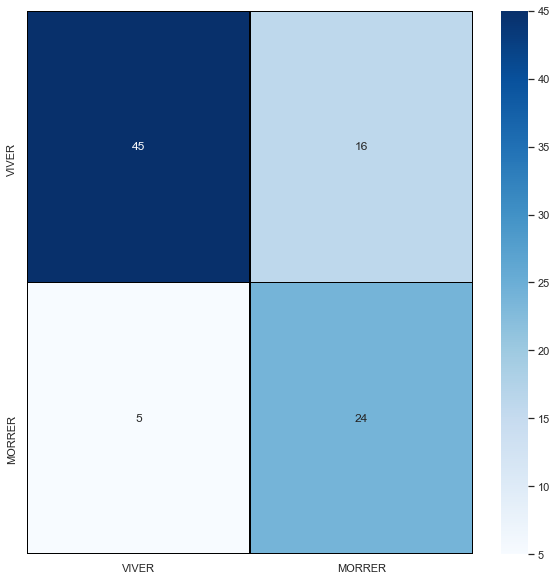

```
AUC: 0.782646
```

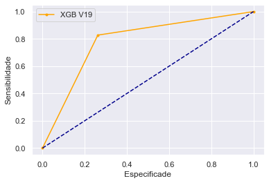

```
Acurácia: 0.766667
              precision    recall  f1-score   support

       VIVER       0.90      0.74      0.81        61
      MORRER       0.60      0.83      0.70        29

    accuracy                           0.77        90
   macro avg       0.75      0.78      0.75        90
weighted avg       0.80      0.77      0.77        90

Report Para Dados de Treino
Acurácia: 0.750000
              precision    recall  f1-score   support

       VIVER       0.77      0.71      0.74       142
      MORRER       0.73      0.79      0.76       142

    accuracy                           0.75       284
   macro avg       0.75      0.75      0.75       284
weighted avg       0.75      0.75      0.75       284

Wall time: 259 ms
```

```python
%%time

#Transformando os dados em DMatrix pois o XGBoost exige
dtrain_sc_resample = xgb.DMatrix(x_train_sc_resample, label = y_train_resample_2)
dtest_sc = xgb.DMatrix(x_test_sc, label = y_test_nothing)

params = {'colsample_bynode': 0.6, 'colsample_bytree': 0.5, 'gamma': 2.2, 'learning_rate': 0.5, 'max_depth': 12,\
          'min_child_weight': 1, 'nthread': 2, 'subsample': 0.789}

# Criação do modelo base v19
# Criando sem feature selecting. Com padronização e balanceamento
modelo_xgb_v19 = xgb.train(params = params, dtrain = dtrain_sc_resample)

pred_v19 = modelo_xgb_v19.predict(dtest_sc)

report_modelo(modelo_xgb_v19, y_test_nothing, pred_v19, label = 'XGB V19', target_names = ['VIVER', 'MORRER'])

print('Report Para Dados de Treino')
pred_treino = modelo_xgb_v19.predict(dtrain_sc_resample)
pred_treino = pred_treino > 0.5

# Acurácia
print("Acurácia: %f" % accuracy_score(y_train_resample_2, pred_treino))

# Classification Report
print(classification_report(y_train_resample_2, pred_treino, target_names= ['VIVER', 'MORRER']))
```

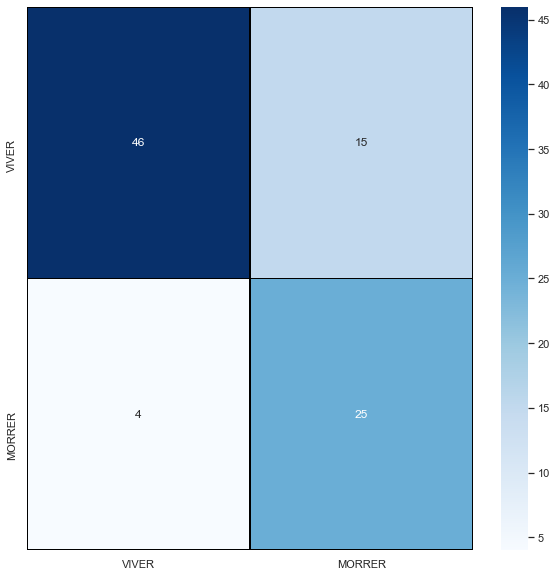

```
AUC: 0.808084
```

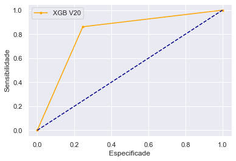

```
Acurácia: 0.788889
              precision    recall  f1-score   support

       VIVER       0.92      0.75      0.83        61
      MORRER       0.62      0.86      0.72        29

    accuracy                           0.79        90
   macro avg       0.77      0.81      0.78        90
weighted avg       0.82      0.79      0.80        90

Report Para Dados de Treino
Acurácia: 0.845070
              precision    recall  f1-score   support

       VIVER       0.87      0.82      0.84       142
      MORRER       0.83      0.87      0.85       142

    accuracy                           0.85       284
   macro avg       0.85      0.85      0.84       284
weighted avg       0.85      0.85      0.84       284

Wall time: 256 ms
```

```python
%%time

#Transformando os dados em DMatrix pois o XGBoost exige
dtrain_sc_resample = xgb.DMatrix(x_train_sc_resample, label = y_train_resample_2)
dtest_sc = xgb.DMatrix(x_test_sc, label = y_test_nothing)

params = {'colsample_bynode': 0.6, 'colsample_bytree': 0.5, 'gamma': 2.2, 'learning_rate': 0.5, 'max_depth': 5,\
          'min_child_weight': 1, 'nthread': 2, 'subsample': 0.789, 'colsample_bylevel': 0.9}

# Criação do modelo base v20
# Criando sem feature selecting. Com padronização e balanceamento
modelo_xgb_v20 = xgb.train(params = params, dtrain = dtrain_sc_resample)

pred_v20 = modelo_xgb_v20.predict(dtest_sc)

report_modelo(modelo_xgb_v20, y_test_nothing, pred_v20, label = 'XGB V20', target_names = ['VIVER', 'MORRER'])

print('Report Para Dados de Treino')
pred_treino = modelo_xgb_v20.predict(dtrain_sc_resample)
pred_treino = pred_treino > 0.5

# Acurácia
print("Acurácia: %f" % accuracy_score(y_train_resample_2, pred_treino))

# Classification Report
print(classification_report(y_train_resample_2, pred_treino, target_names= ['VIVER', 'MORRER']))
```

# 7. Conclusão

Após uma vasto trabalho no problema, conseguimnos atingir um Recall que satisfaz o problema. O objetivo era um Recall de 75% para a classe 0 (VIVER) e 85% para a classe 1 (MORRER), atingimos 75% e 86%, respectivamente. Ao longo do notebook foram encontrado alguns problemas com o dataset, como o seu tamanho que é muito pequeno, 299 observações, desbalanceamento entre as classes, alguns dados de baixissima qualidade...

Porém com um alto processamento nos dados, e uma modelagem intensa sobre os algoritmos de Machine Learning conseguimos reduzir o overfitting e alcançar um Recall desejado. É importante ressaltar que todos os valores abaixo foram testados com diversas modificações, tentando explorar ao maximo o espaço de hipotese.

Ao longo do treinamento foram utilizados 3 algoritmos, primeiro iniciamos vendo a disposição dos dados com o algoritmo K-Means, logo após iniciamos a modelagem com o algoritmo SVM, onde tivemos muitas dificuldades devido ao numero de observações. Assim, partimos para um algoritmo que lida melhor com menores quantidades de dados o XGBoost, onde com alta modelagem dos hiperparametros atingimos as métricas desejadas.

Abaixo segue as especificações utilizadas para o resultado final:

- Feature Selecting: Não. Todas variaveis utilizadas.
- Padronização: Sim. Somente nas variaveis independentes.
- Balanceamento (SMOTE): Sim. Somente no dataset de treino.
- Algoritmo: XGBoost
- Parâmetros: {'colsample_bynode': 0.6, 'colsample_bytree': 0.5, 'gamma': 2.2, 'learning_rate': 0.5, 'max_depth': 5, 'min_child_weight': 1, 'nthread': 2, 'subsample': 0.789, 'colsample_bylevel': 0.9}

Abaixo segue o treinamento do modelo final escolhido conforme os parâmetros acima:

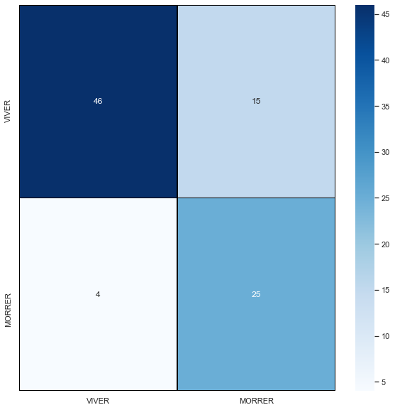

```
AUC: 0.808084
```

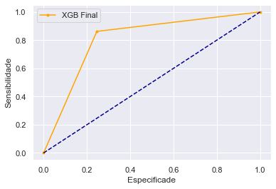

```
Acurácia: 0.788889
              precision    recall  f1-score   support

       VIVER       0.92      0.75      0.83        61
      MORRER       0.62      0.86      0.72        29

    accuracy                           0.79        90
   macro avg       0.77      0.81      0.78        90
weighted avg       0.82      0.79      0.80        90

Report Para Dados de Treino
Acurácia: 0.845070
              precision    recall  f1-score   support

       VIVER       0.87      0.82      0.84       142
      MORRER       0.83      0.87      0.85       142

    accuracy                           0.85       284
   macro avg       0.85      0.85      0.84       284
weighted avg       0.85      0.85      0.84       284
```

```python
# Transformando os dados em DMatrix pois o XGBoost exige
dtrain_sc_resample = xgb.DMatrix(x_train_sc_resample, label = y_train_resample_2)
dtest_sc = xgb.DMatrix(x_test_sc, label = y_test_nothing)

params = {'colsample_bynode': 0.6, 'colsample_bytree': 0.5, 'gamma': 2.2, 'learning_rate': 0.5, 'max_depth': 5,\
          'min_child_weight': 1, 'nthread': 2, 'subsample': 0.789, 'colsample_bylevel': 0.9}

# Criação do modelo base final
# Criando sem feature selecting. Com padronização e balanceamento
modelo_xgb_final = xgb.train(params = params, dtrain = dtrain_sc_resample)

pred_final = modelo_xgb_final.predict(dtest_sc)

report_modelo(modelo_xgb_final, y_test_nothing, pred_final, label = 'XGB Final', target_names = ['VIVER', 'MORRER'])

print('Report Para Dados de Treino')
pred_treino = modelo_xgb_final.predict(dtrain_sc_resample)
pred_treino = pred_treino > 0.5

# Acurácia
print("Acurácia: %f" % accuracy_score(y_train_resample_2, pred_treino))

# Classification Report
print(classification_report(y_train_resample_2, pred_treino, target_names= ['VIVER', 'MORRER']))
```